# Project 4: Movie Recommendation

Tatiana Sokolinski, tatiana9@illinois.edu

Noam Mansovsky, noamm2@illinois.edu

12/11/2021

## Read in Data

### Ratings data:

```r
myurl = "https://liangfgithub.github.io/MovieData/"
ratings = read.csv(paste0(myurl, 'ratings.dat?raw=true'),
                   sep = ':',
                   colClasses = c('integer', 'NULL'),
                   header = FALSE)
colnames(ratings) = c('UserID', 'MovieID', 'Rating', 'Timestamp')
head(ratings, 5)
```

```
##   UserID MovieID Rating Timestamp
## 1      1    1193      5 978300760
## 2      1     661      3 978302109
## 3      1     914      3 978301968
## 4      1    3408      4 978300275
## 5      1    2355      5 978824291
```

### User data:

```r
users = read.csv(paste0(myurl, 'users.dat?raw=true'),
                 sep = ':', header = FALSE)
users = users[, -c(2,4,6,8)] # skip columns
colnames(users) = c('UserID', 'Gender', 'Age', 'Occupation', 'Zip-code')
head(users, 5)
```

```
##   UserID Gender Age Occupation Zip-code
## 1      1      F   1         10    48067
## 2      2      M  56         16    70072
## 3      3      M  25         15    55117
## 4      4      M  45          7    02460
## 5      5      M  25         20    55455
```

### Movies data:

```r
movies = readLines(paste0(myurl, 'movies.dat?raw=true'))
movies = strsplit(movies, split = "::", fixed = TRUE, useBytes = TRUE)
movies = matrix(unlist(movies), ncol = 3, byrow = TRUE)
movies = data.frame(movies, stringsAsFactors = FALSE)
colnames(movies) = c('MovieID', 'Title', 'Genres')
movies$MovieID = as.integer(movies$MovieID)

# convert accented characters
movies$Title[73]
```

```
## [1] "Mis\xe9rables, Les (1995)"
```

```r
movies$Title = iconv(movies$Title, "latin1", "UTF-8")
movies$Title[73]
```

```
## [1] "Misérables, Les (1995)"
```

```r
# extract year
movies$Year = as.numeric(unlist(
  lapply(movies$Title, function(x) substr(x, nchar(x)-4, nchar(x)-1))))
head(movies, 5)
```

```
##   MovieID                              Title                       Genres Year
## 1       1                   Toy Story (1995)  Animation|Children's|Comedy 1995
## 2       2                     Jumanji (1995) Adventure|Children's|Fantasy 1995
## 3       3            Grumpier Old Men (1995)               Comedy|Romance 1995
## 4       4           Waiting to Exhale (1995)                 Comedy|Drama 1995
## 5       5 Father of the Bride Part II (1995)                       Comedy 1995
```

# System I: Content-Based Recommendation System

## 1. Recommend the top-five “highly-rated” movies in the selected genre:

**Examine the data:**

Number of moview in each rating category:

```r
# Count the number of movies in each rating category:
ratings %>% group_by(Rating) %>% summarize(n=n())
```

```
## # A tibble: 5 × 2
##   Rating      n
##    <int>  <int>
## 1      1  56174
## 2      2 107557
## 3      3 261197
## 4      4 348971
## 5      5 226310
```

Average number of time movie receives the rating:

```r
# Count the number of time movie receives the rating:
rating_cnt <- ratings %>% group_by(MovieID) %>% summarize(n=n())
head(rating_cnt)
```

```
## # A tibble: 6 × 2
##   MovieID     n
##     <int> <int>
## 1       1  2077
## 2       2   701
## 3       3   478
## 4       4   170
## 5       5   296
## 6       6   940
```

The plot below shows distribution of number of movies ratings. On average movie received about 269.8891 users reviews.

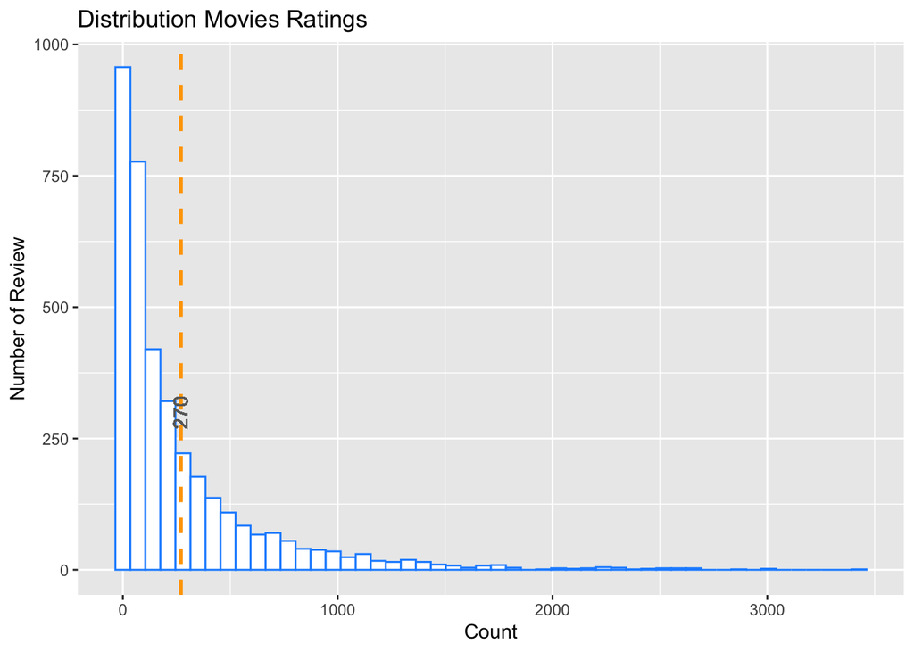

```r
ggplot(rating_cnt, aes(x=n)) +
    geom_histogram(colour="DodgerBlue", fill="white",bins=50) +
    geom_vline(aes(xintercept=mean(n, na.rm=T)),
               color="orange", linetype="dashed", size=1)+
  ggtitle("Distribution Movies Ratings") +
  geom_text(aes(x=mean(n, na.rm=T), label=round(mean(n, na.rm=T)), y=300), colour="DimGrey", angle=90) +
  xlab("Count") + ylab("Number of Review")
```

- **Create a table that summarizes all genres for each movie:**

```r
# Subset Genres column
genres <- as.data.frame(movies$Genres, stringsAsFactors=FALSE)
# Split text on pipe to get all genres for each movie
tmp = as.data.frame(tstrsplit(genres[,1], '[|]',
                              type.convert=TRUE),
                    stringsAsFactors=FALSE)
colnames(tmp) <- c(1:dim(tmp)[2])
head(tmp)
```

```
##           1          2        3    4    5    6
## 1 Animation Children's   Comedy <NA> <NA> <NA>
## 2 Adventure Children's  Fantasy <NA> <NA> <NA>
## 3    Comedy    Romance     <NA> <NA> <NA> <NA>
## 4    Comedy      Drama     <NA> <NA> <NA> <NA>
## 5    Comedy       <NA>     <NA> <NA> <NA> <NA>
## 6    Action      Crime Thriller <NA> <NA> <NA>
```

- **Create the movie feature matrix with binary indicator for each genre:**

```r
genre_list = c("Action", "Adventure", "Animation",
               "Children's", "Comedy", "Crime",
               "Documentary", "Drama", "Fantasy",
               "Film-Noir", "Horror", "Musical",
               "Mystery", "Romance", "Sci-Fi",
               "Thriller", "War", "Western")

genre_matrix = matrix(0, nrow(movies), length(genre_list))
# Loop over all movies
for(i in 1:nrow(tmp)){
  genre_matrix[i,genre_list %in% tmp[i,]]=1
}
colnames(genre_matrix) = genre_list
head(genre_matrix)
```

```
##      Action Adventure Animation Children's Comedy Crime Documentary Drama
## [1,]      0         0         1          1      1     0           0     0
## [2,]      0         1         0          1      0     0           0     0
## [3,]      0         0         0          0      1     0           0     0
## [4,]      0         0         0          0      1     0           0     1
## [5,]      0         0         0          0      1     0           0     0
## [6,]      1         0         0          0      0     1           0     0
##      Fantasy Film-Noir Horror Musical Mystery Romance Sci-Fi Thriller War
## [1,]       0         0      0       0       0       0      0        0   0
## [2,]       1         0      0       0       0       0      0        0   0
## [3,]       0         0      0       0       0       1      0        0   0
## [4,]       0         0      0       0       0       0      0        0   0
## [5,]       0         0      0       0       0       0      0        0   0
## [6,]       0         0      0       0       0       0      0        1   0
##      Western
## [1,]       0
## [2,]       0
## [3,]       0
## [4,]       0
## [5,]       0
## [6,]       0
```

- **Create the user profile matrix:**

```r
ratings = ratings[, -c(4)]
ratings_long <- dcast(ratings, MovieID~UserID, value.var = "Rating", na.rm=FALSE)
# for (i in 1:ncol(ratings_long)){
#   ratings_long[which(is.na(ratings_long[,i]) == TRUE),i] <- 0
# }
ratings_long <- ratings_long[,-1] #remove movieIds col. Rows are movieIds, cols are userIds
# Remove movies with no reviews
ratings_long <- ratings_long[rowSums(is.na(ratings_long)) != ncol(ratings_long), ]
ratings_long[1:6, 1:9]
```

```
##    1  2  3  4  5  6  7  8  9
## 1  5 NA NA NA NA  4 NA  4  5
## 2 NA NA NA NA NA NA NA NA NA
## 3 NA NA NA NA NA NA NA NA NA
## 4 NA NA NA NA NA NA NA  3 NA
## 5 NA NA NA NA NA NA NA NA NA
## 6 NA NA NA NA  2 NA  4 NA NA
```

- **Recommend top-five highly-rated movies in the selected genre:**

The methodology to find the top-five **“highly-rated”** movies. For each movie we calculate movie weighted rating score:

Movie Weighted Rating $(MWR) = (\frac{v}{v + m}) * R + (\frac{m}{v + m})*C$

Where:

- R - average rating for the movie
- v - count of reviews for the movie
- m - minimum review needed to be considered for “highly-rated” category. Since on average movie receives 270 users reviews, we can consider only movies with 50 or more reviews. m = 50
- C - constant that represent the average rating for the movie in this genre.

```r
# Select genre
genre <- genre_list[18]
genre
```

```
## [1] "Western"
```

```r
# List of movies of this genre
movie_list <- which(genre_matrix[,c(genre)] == 1)
movies_options <- ratings_long[movie_list, ]

m = 50
# Average movie review
R <- rowMeans(movies_options, na.rm = TRUE)
# Number of reviews received
v <- rowSums(!is.na(movies_options))
# Average rating for the movie in this genre
C <- mean(R, na.rm = TRUE)
# Compute Movie Weighted Rating
movies_options['MWR'] = (v / (v + m)) * R + (m / (m +v)) * C
movies_options['indx'] <- movie_list
movies_options['ave_rating'] <- R
movies_options['n_reviews'] <- v
```

Recommend top-five “highly-rated” movies:

```r
# Select the top-five "highly-rated" movies in the specified genre
table <- movies_options[movies_options$n_reviews >=50, c('indx','n_reviews','MWR')]
rows <- table[which.maxn(table$MWR, n=5) , 'indx']
# Recommend movies
movies[rows,]
```

```
##      MovieID                               Title         Genres Year
## 1192    1209 Once Upon a Time in the West (1969)        Western 1969
## 1264    1283                    High Noon (1952)        Western 1952
## 484      487               Lightning Jack (1994) Comedy|Western 1994
## 3576    3644                 Dark Command (1940)        Western 1940
## 1247    1266                   Unforgiven (1992)        Western 1992
```

## 2. Recommend the top-five “most-popular” movies in the selected genre:

- **Create the user profile matrix:**

This time the user profile matrix uses a binary indicator “1” when a movie rating equals 4 or 5 and “0” when a movie rating equals 1,2 or 3.

```r
ratings_binary <- ratings
ratings_binary$Rating[ratings_binary$Rating == 1 | ratings_binary$Rating == 2 | ratings_binary$Rating == 3 ] <- 0
ratings_binary$Rating[ratings_binary$Rating == 4 | ratings_binary$Rating == 5 ] <- 1
ratings_binary = ratings_binary[, -c(4)]
head(ratings_binary)
```

```
##   UserID MovieID Rating
## 1      1    1193      1
## 2      1     661      0
## 3      1     914      0
## 4      1    3408      1
## 5      1    2355      1
## 6      1    1197      0
```

Transform the binary rating dataset from a long format to a wide format:

```r
ratings_binary_long <- dcast(ratings_binary, MovieID~UserID, value.var = "Rating", na.rm=FALSE)
ratings_binary_long = ratings_binary_long[,-1] #remove movieIds col. Rows are movieIds, cols are userIds
head(ratings_binary_long[1:6,1:6])
```

```
##    1  2  3  4  5  6
## 1  1 NA NA NA NA  1
## 2 NA NA NA NA NA NA
## 3 NA NA NA NA NA NA
## 4 NA NA NA NA NA NA
## 5 NA NA NA NA NA NA
## 6 NA NA NA NA  0 NA
```

- **Recommend top-five most-popular movies in the selected genre:**

The methodology to find the top-five **“most-popular”** movies. For each movie we calculate movie popularity score:

Movie Popularity Score $(MPS) = P + P * \frac{P}{N}$

Where:

- P - count of positive reviews (where user’s review >= 4)
- N - count of negative reviews (where user’s review <= 3)

```r
# Select genre
genre <- genre_list[18]
genre
```

```
## [1] "Western"
```

```r
# List of movies of this genre
movie_list <- which(genre_matrix[,c(genre)] == 1)
movies_options <- ratings_binary_long[movie_list, ]


# Number of reviews received
v <- rowSums(!is.na(movies_options))

# Total positive and negative reviews
positive_reviews <- rowSums(movies_options, na.rm = TRUE)
negative_reviews <- v - positive_reviews

movies_options['indx'] <- movie_list
movies_options['n_reviews'] <- v
movies_options['pos_reviews'] <- positive_reviews
movies_options['neg_reviews'] <- negative_reviews
movies_options['ratio'] <- positive_reviews / negative_reviews
movies_options['MPS'] <- positive_reviews + positive_reviews * movies_options['ratio']
data <- movies_options[, c('indx','n_reviews','pos_reviews','neg_reviews','ratio','MPS')]
data <- data %>% mutate(MPS = coalesce(MPS, 0)) # fill na with zeros
data <- data %>% mutate_if(is.numeric, function(x) ifelse(is.infinite(x), 0, x)) # fill na with zeros
```

Recommend top-five “most-popular” movies:

```r
# Select the top-five "most-popular" movies in the specified genre
rows <- table[which.maxn(data$MPS, n=5) , 'indx']
# Recommend movies
movies[rows,]
```

```
##      MovieID                         Title         Genres Year
## 953      964   Angel and the Badman (1947)        Western 1947
## 2333    2401             Pale Rider (1985)        Western 1985
## 1987    2055 Hot Lead and Cold Feet (1978) Comedy|Western 1978
## 3614    3682           Magnum Force (1973)        Western 1973
## 2410    2478          Three Amigos! (1986) Comedy|Western 1986
```

# System II: Collaborative Recommendation System

## 1. User-based recommendation:

User-Based Collaborative Filtering is an algorithm used to predict the items that a user might like on the basis of ratings given by the other users who have similar taste with that of the target user.

- **Create the user profile matrix:**

Create ratings matrix using MovieID, UserID and Ratings fields.

```r
# Create ratings matrix. Rows = UserID, Columns = MovieID
ratingmat_raw = matrix(nrow = 6040, ncol = 3952)
for (ix in 1:nrow(ratings)){
  row = as.list(ratings[ix, ][1:3])
  ratingmat_raw[row$UserID, row$MovieID] = row$Rating
}
```

```r
ratingmat <- as.matrix(ratingmat_raw, dimnames = c("UserID","MovieID"))
rownames(ratingmat) = 1:6040
colnames(ratingmat) = 1:3952
# Convert rating matrix into a recommenderlab sparse matrix
ratingmat <- as(ratingmat, "realRatingMatrix")
dim(ratingmat)
```

```
## [1] 6040 3952
```

- **Train and test splits:**

The `evaluationScheme()` function can split the data set into training and testing subsets:

- **train** matrix contains about 80% rows of `rating` dataset
- **test** matrix contains about 20% rows of `rating` dataset

The output of the evaluationScheme() function is a single R object containing both the training and testing subsets.

```r
set.seed(9335)
# Parameters:
percent_train = 0.8 # split the data into the training and the test sets (80%/20%)
items_to_keep = 15  # items to use for each user
rating_threshold = 4 # threshold at which ratings are considered good for evaluation
eval_sets <- evaluationScheme(ratingmat, method="split", train=percent_train, given=items_to_keep, goodRating=rating_threshold)
eval_sets
```

```
## Evaluation scheme with 15 items given
## Method: 'split' with 1 run(s).
## Training set proportion: 0.800
## Good ratings: >=4.000000
## Data set: 6040 x 3952 rating matrix of class 'realRatingMatrix' with 1000209 ratings.
```

- **Build Recommender Model**

Build Recommender Model using User-Based Collaborative Filtering using `recommenderlab` library. Set method equals to “UBCF”, use Cosine Similarity, Z-score normalization and 30 Nearest Neighbors as parameters.

```r
# Create Recommender Model using User-Based Collaborative Filtering
UBCF_model <- Recommender(getData(eval_sets, "train"), "UBCF",
                           param=list(normalize = "Z-score",method="Cosine",nn=30))
```

- **Evaluate your model:**

To evaluate the model we use the `recommenderlab` package. We first use the `predict()` function to generate predictions for the known portion of the test data. Then, the `calcPredictAccuracy()` function to calculate the error between the predictions and the unknown portions of the test data.

```r
items_to_recommend = 10
UBCF_eval_prediction = predict(object = UBCF_model,
                          newdata = getData(eval_sets, "known"),
                          n = items_to_recommend,
                          type = "ratings")
# Get model performance
UBCF_eval_accuracy = calcPredictionAccuracy(x = UBCF_eval_prediction,
                                       data = getData(eval_sets, "unknown"),
                                       byUser = FALSE)
UBCF_eval_accuracy
```

```
##   RMSE    MSE    MAE
## 1.1475 1.3167 0.8853
```

- **Get recommendations:**

```r
# Obtain top 10 recommendations for n user in dataset
items_to_recommend = 10
a_user_id = 1
recom <- predict(UBCF_model, ratingmat[a_user_id], n=items_to_recommend)
recom_list <- as(recom, "list") #convert recommenderlab object to readable list

# Obtain recommendations
recom_result <- matrix(0,items_to_recommend)
for (i in c(1:items_to_recommend)){
 recom_result[i] <- movies[as.integer(recom_list[[1]][i]),2]
}
recom_result
```

```
##       [,1]
##  [1,] "Usual Suspects, The (1995)"
##  [2,] "Frankenstein (1931)"
##  [3,] "Disclosure (1994)"
##  [4,] "Whatever It Takes (2000)"
##  [5,] "Boat, The (Das Boot) (1981)"
##  [6,] "Dracula: Dead and Loving It (1995)"
##  [7,] "Tom & Viv (1994)"
##  [8,] "Tommy Boy (1995)"
##  [9,] "Short Cuts (1993)"
## [10,] "Tin Cup (1996)"
```

## 2. Item-based recommendation:

Item-based recommendation is a form of collaborative filtering for recommender systems that uses the similarity between items which calculated using people’s ratings of those items.

- **Build Recommender Model**

Build Recommender Model using Item-Based Collaborative Filtering using `recommenderlab` library. Set method equals to “IBCF”, use Cosine Similarity as parameters.

```r
# Create Recommender Model using Item-Based Collaborative Filtering
IBCF_model <- Recommender(getData(eval_sets, "train"), "IBCF",
                           param=list(normalize = "Z-score",method="Cosine",k=30))
```

- **Evaluate your model:**

To evaluate the model we use the `recommenderlab` package. We first use the `predict()` function to generate predictions for the known portion of the test data. Then, the `calcPredictAccuracy()` function to calculate the error between the predictions and the unknown portions of the test data.

```r
items_to_recommend = 10
IBCF_eval_prediction = predict(object = IBCF_model,
                          newdata = getData(eval_sets, "known"),
                          n = items_to_recommend,
                          type = "ratings")
# Get model performance
IBCF_eval_accuracy = calcPredictionAccuracy(x = IBCF_eval_prediction,
                                       data = getData(eval_sets, "unknown"),
                                       byUser = FALSE)
IBCF_eval_accuracy
```

```
##  RMSE   MSE   MAE
## 1.538 2.365 1.136
```

- **Get recommendations:**

```r
# Obtain top 10 recommendations for n user in dataset
a_user_id = 15
recom <- predict(IBCF_model, ratingmat[a_user_id], n=items_to_recommend)
recom_list <- as(recom, "list") #convert recommenderlab object to readable list

# Obtain recommendations
recom_result <- matrix(0,items_to_recommend)
for (i in c(1:items_to_recommend)){
 recom_result[i] <- movies[as.integer(recom_list[[1]][i]),2]
}
recom_result
```

```
##       [,1]
##  [1,] "August (1996)"
##  [2,] "Keys to Tulsa (1997)"
##  [3,] "My Cousin Vinny (1992)"
##  [4,] "My Best Girl (1927)"
##  [5,] "Who's That Girl? (1987)"
##  [6,] "Grumpy Old Men (1993)"
##  [7,] "Groove (2000)"
##  [8,] "Silent Fall (1994)"
##  [9,] "Little Rascals, The (1994)"
## [10,] "Lone Star (1996)"
```

## 3. Report User-based vs. Item-based accuracy:

Both models use Cosine Similarity, Z-score normalization and 30 nearest neighbors or items as parameters.

```r
# Aggregate the performance statistics
performance <- rbind(
 UBCF_eval_accuracy,
 IBCF_eval_accuracy
)
kable(performance)
```

|  | RMSE | MSE | MAE |
| --- | --- | --- | --- |
| UBCF_eval_accuracy | 1.147 | 1.317 | 0.8853 |
| IBCF_eval_accuracy | 1.538 | 2.365 | 1.1363 |

User-based collaborative model (UBCF) outperforms Item-based collaborative model (IBCF). On the other hand, UBCF has greater computational cost and requires more resources.

## Team Members Contribution:

Data Preprocessing & Models: Tatiana & Noam Models Development: Tatiana Web App: Noam Report: Tatiana & Noam